PCA and population structure

# Simple example of PCA and MDS

First let's try to perform PCA and MDS on the small matrix from the slides. The below code will input the genotypes into R.

```
#read in data from slides
G <-matrix(c(1,0,2,0,2,0,2,1,1,1,0,1,0,2,1,2,1,1,1,1,1,0,1,0,2,0,1,1,0,2,1,2,0,1,0),5,by=T,
           dimnames=list(paste0("IND",1:5),paste0("SNP",1:7)))
nInd <- nrow(G)

print(G)
```

```
     SNP1 SNP2 SNP3 SNP4 SNP5 SNP6 SNP7
IND1    1    0    2    0    2    0    2
IND2    1    1    1    0    1    0    2
IND3    1    2    1    1    1    1    1
IND4    0    1    0    2    0    1    1
IND5    0    2    1    2    0    1    0
```

```
## run the code to start a quiz
from jupyterquiz import display_quiz
display_quiz('https://raw.githubusercontent.com/popgenDK/courses/main/kenya2024/exercises/day3_PopulationStructure/pca_quiz1.json')
```

## MDS

Let's try to do multidimensional scaling (MDS). First let's calculate the distance. The simple distance measure as seen in the slides is called a Manhattan distance.

```
## continue in R
D<-dist(G,upper=T,diag=T,method="manh")
D
```

```
     IND1 IND2 IND3 IND4 IND5
IND1    0    3    7   10   11
IND2    3    0    4    7    8
IND3    7    4    0    5    4
IND4   10    7    5    0    3
IND5   11    8    4    3    0
```

- How many dimensions are used to represent the distances?

Now let's reduce the number of dimension to 2 using MDS and plot the results:

```
#perform MDS to 2 dimensions
k2<-cmdscale(D,k=2)

cat("\n Dimension reduction to two dimensions")
k2
cat("\n original Distance between individuals:")
dist(G,upper=T,diag=T,method="manha")
cat("\n Distance between individuals in from the MDS:")
round(D_k2<- dist(k2,upper=T,diag=T,method="manha"),2)
```

```
 Dimension reduction to two dimensions
```

A matrix: 5 × 2 of type dbl

| IND1 | 6.114866 | 0.2977272 |
| --- | --- | --- |
| IND2 | 3.077094 | 0.2402932 |
| IND3 | -0.621230 | -1.7944048 |
| IND4 | -3.723118 | 2.1483083 |
| IND5 | -4.847612 | -0.8919238 |

```
 original Distance between individuals:
```

```
     IND1 IND2 IND3 IND4 IND5
IND1    0    3    7   10   11
IND2    3    0    4    7    8
IND3    7    4    0    5    4
IND4   10    7    5    0    3
IND5   11    8    4    3    0
```

```
 Distance between individuals in from the MDS:
```

```
      IND1  IND2  IND3  IND4  IND5
IND1  0.00  3.10  8.83 11.69 12.15
IND2  3.10  0.00  5.73  8.71  9.06
IND3  8.83  5.73  0.00  7.04  5.13
IND4 11.69  8.71  7.04  0.00  4.16
IND5 12.15  9.06  5.13  4.16  0.00
```

- What is the biggest difference between the original distances and the projected?

Lets plot the results

```
#plot the results
options(repr.plot.width=10, repr.plot.height=10)
plot(k2,pch=16,cex=3,col=1:5+1,ylab="distance 2nd dimension",xlab="distance 1st dimension",main="Multiple dimension scaling (MDS)")
points(k2,pch=as.character(1:5), col="white")
```

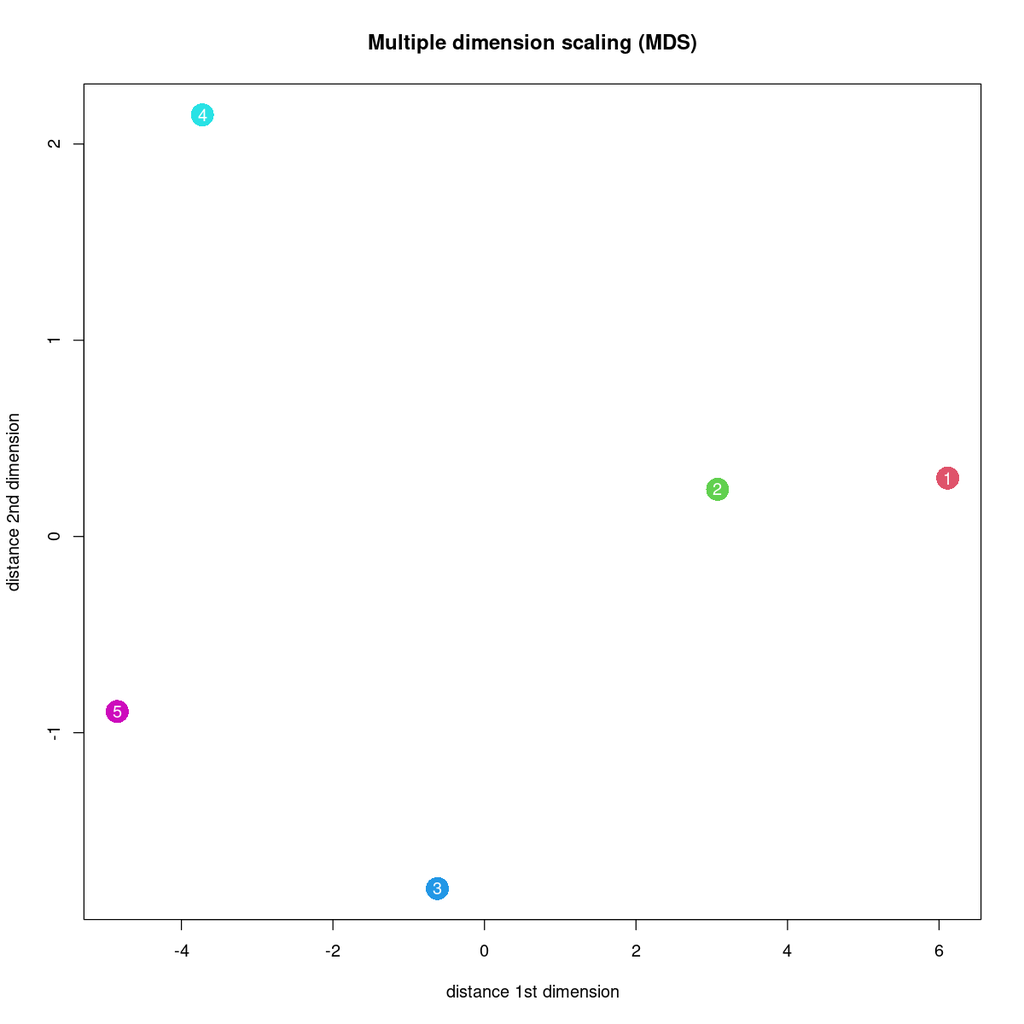

- Can you find any difference in the pairwise distances from the plot and the original pairwise distances?.

## PCA

First let's try to perform PCA directy on the normalized genotypes without calculating the covariance matrix. We use the normalization $\tilde{G}_{ij}=\frac{G_{ij}-2f_j}{\sqrt{2f_j(1-f_j)}}$ where j is the site (SNP) and i is the individuals. $f_j=\frac{\sum_i^n G_{ij}}{2n}$ is the allele frequency.

- Why do we normalize the genotypes?

```
#first normalize the data do that the mean and variance is the same for each SNP
normalize <- function(x){
    nInd <- nrow(x)
    avg <- colMeans(x)
    M <- x - rep(colMeans(x),each=nInd)
    M <- M/sqrt(2*rep(avg/2*(1-avg/2),each=nInd))
    M
 }


cat("Original genotypes\n")
print(G)

cat("\n Normalizes genotypes\n")
Gtilde <- normalize(G)
print(Gtilde)

cat("\n Dimension of G-tilde (tilde = ~)")
dim(Gtilde)


cat("\n Dimension of G-tilde")
 svd <- svd(Gtilde)
 ## print the decomposition for M=SDV
 ## u is the eigenvectors
 ## d is eigen values
 print(svd)
```

```
Original genotypes
     SNP1 SNP2 SNP3 SNP4 SNP5 SNP6 SNP7
IND1    1    0    2    0    2    0    2
IND2    1    1    1    0    1    0    2
IND3    1    2    1    1    1    1    1
IND4    0    1    0    2    0    1    1
IND5    0    2    1    2    0    1    0

 Normalizes genotypes
           SNP1       SNP2      SNP3      SNP4       SNP5       SNP6       SNP7
IND1  0.6172134 -1.7320508  1.414214 -1.414214  1.7320508 -0.9258201  1.1547005
IND2  0.6172134 -0.2886751  0.000000 -1.414214  0.2886751 -0.9258201  1.1547005
IND3  0.6172134  1.1547005  0.000000  0.000000  0.2886751  0.6172134 -0.2886751
IND4 -0.9258201 -0.2886751 -1.414214  1.414214 -1.1547005  0.6172134 -0.2886751
IND5 -0.9258201  1.1547005  0.000000  1.414214 -1.1547005  0.6172134 -1.7320508

 Dimension of G-tilde (tilde = ~)
```

1. 5

2. 7

```
 Dimension of G-tilde$d
[1] 5.261803e+00 2.053667e+00 1.566501e+00 9.253336e-01 3.748163e-16

$u
            [,1]        [,2]       [,3]       [,4]      [,5]
[1,]  0.64933919  0.09424370 -0.5834128 -0.1706056 0.4472136
[2,]  0.35989402  0.07538164  0.5914222  0.5612608 0.4472136
[3,] -0.07799398 -0.60916998  0.3226848 -0.5645382 0.4472136
[4,] -0.39798601  0.72856890  0.1094660 -0.3143433 0.4472136
[5,] -0.53325321 -0.28902426 -0.4401602  0.4882264 0.4472136

$v
           [,1]       [,2]         [,3]       [,4]        [,5]
[1,]  0.2730876 -0.3302541  0.325740175 -0.2899575  0.35747149
[2,] -0.3457940 -0.6975136  0.429315165  0.1470835 -0.03356696
[3,]  0.2814894 -0.4368143 -0.625520546  0.2196783  0.50269419
[4,] -0.5215403  0.1858741 -0.305776626 -0.3312989  0.32151510
[5,]  0.4335716 -0.2426873 -0.232855131 -0.5373485 -0.52610467
[6,] -0.2959595 -0.1274489 -0.007889476 -0.6514342  0.16605338
[7,]  0.4231225  0.3223520  0.412944032 -0.1521959  0.45897074
```

The above is the decomposition of the genotypes into the diagonal matrix (d) with eigenvalues, and the left (u) and right (v) eigenvectors such that $\tilde{G}=U\Sigma V^T$ where $\Sigma$ has the diagonal values of d.

PCA plots in genetics is often with the U matrix or $U\Sigma$

```
plot(svd$u[,1:2],pch=16,cex=3,col=1:5+1,ylab="2. PC",xlab="1. PC",
     main="Principle component analysis (PCA) U matrix")
points(svd$u[,1:2],pch=as.character(1:5), col="white")

cat("SIGMA (diagonal matrix)")
SIGMA <-  diag(svd$d)
plot(svd$u[,1:2]%*%SIGMA[1:2,1:2],pch=16,cex=3,col=1:5+1,ylab="2. PC",xlab="1. PC",
     main="Principle component analysis (PCA) UΣ")
points(svd$u[,1:2]%*%SIGMA[1:2,1:2],pch=as.character(1:5), col="white")
```

```
SIGMA (diagonal matrix)
```

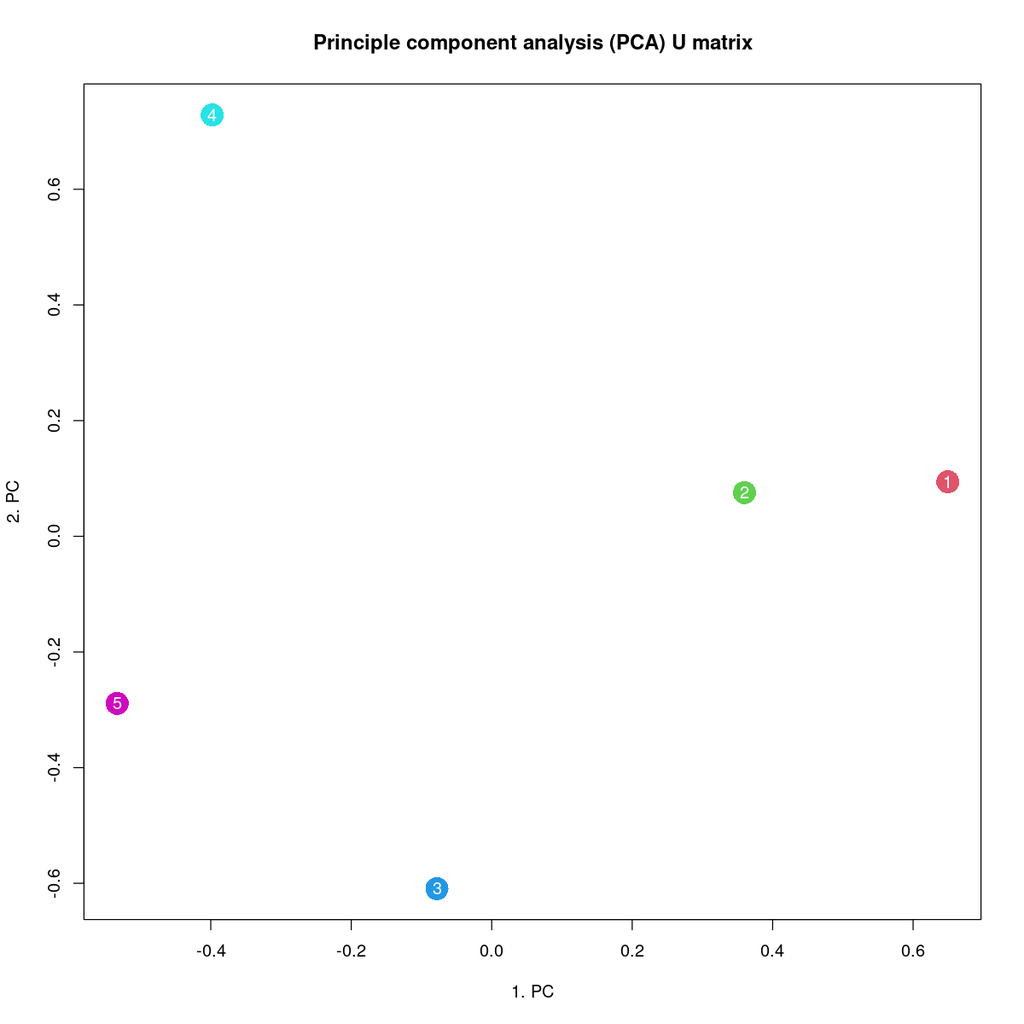

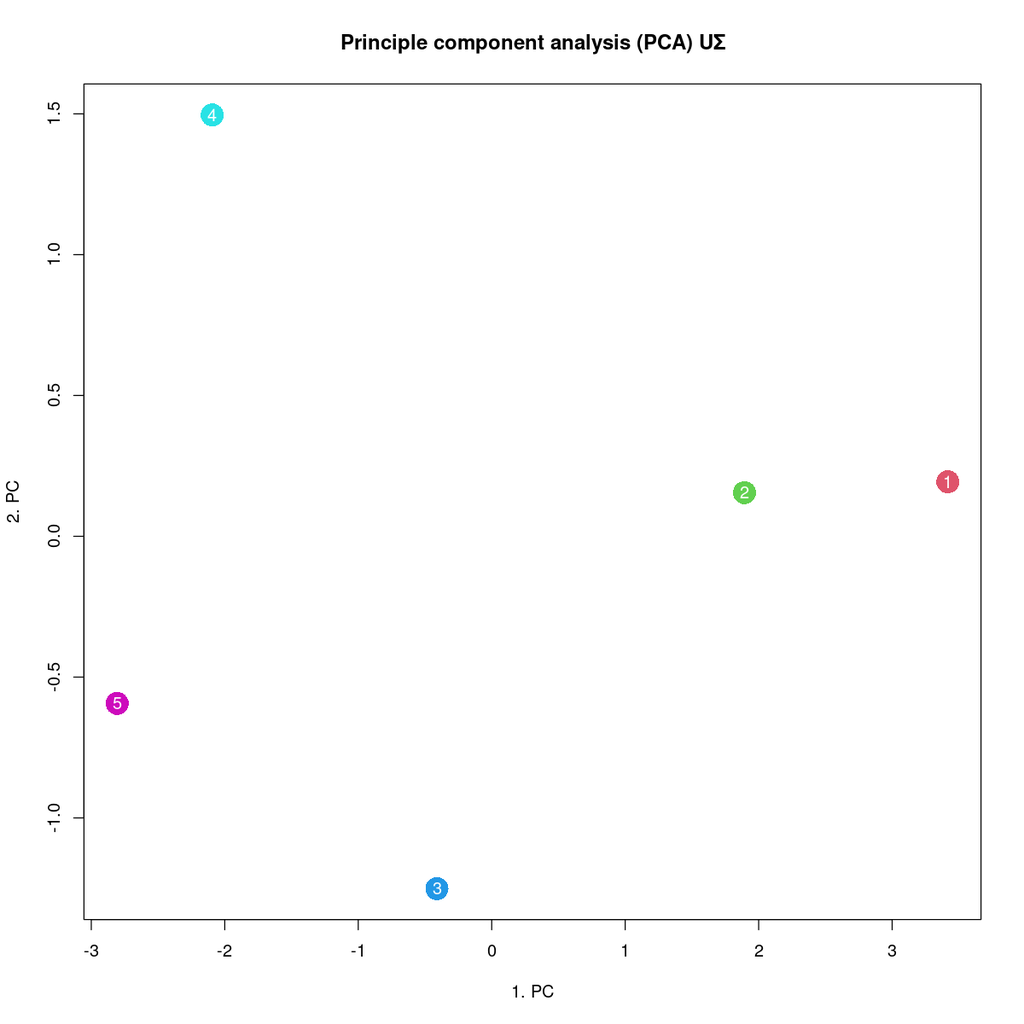

- Compare the two plots. What is the difference?
- Compare MDS vs. PCA. Are the capturing the same thing?

Bonus information:

Unlike MDS, PCA will not remove information, so you are actually able to reconstruct your covariance matrix from the principal components.